# Highway ramp exploration

### Purpose & Motivation

As we have discovered with previous analysis, a set of oscillations in traffic flow (wiggles) appears within the mean flow of the main-line highway sensors (ie. main lanes of travel). These fluctuations exhibit a period of approximately $\frac{1}{2}$ hour.

We have hypothesized these wiggles are an artifact of the natural rhythm of travelers attempting to arrive at their destination or leaving from their start point on the hour or half-hour. However, it is also possible that these fluctuations are due to the method by which the data is collected and processed. The following analysis attempts to discover evidence that the oscillations are not an artifact of data collection.

### Hypothesis

On-ramp and off-ramp mean flow data exhibit patterns (oscillations) which can be correlated to oscillations in the mean flow of the main-line (eg. phase shifted). In particular we hypothesis the following are true:

- Areas of high commercial concentration will experience peaks in the off-ramp oscillations just *prior to* the hour and half-hour during the *morning* hours.
- These same commercial-heavy areas will experience peaks in on-ramp oscillations just *after* the hour and half-hour during the *evening* hours.
- Areas of high residential concentration will experience valleys in the on-ramp oscillations near the hour and half-hour during the *morning* hours.

### Tasks/Questions to Answer

#### Questions to Answer

- What patterns (if any) exist in the off-ramp mean flow oscillations in the morning and evening?
- What patterns (if any) exist in the on-ramp mean flow oscillations in the morning and evening?
- How are these patterns related to the mean main-line flow oscillations?

#### Tasks

- Select data subset (in this case, I-5 South for the year 2015)
- Calculate mean flow for each station (station-day vector)
- Calculate smoothed mean flow for each station
- Subtract smoothed mean from raw mean to isolate oscillations (wiggles) for each station
- Identify station clusters (on-ramp and/or off-ramp plus main-line stations preceding and anteceding)
- Plot station clusters

### I-5 South, Poinsettia Ln. (6 - 9am) [[Google Maps]](https://www.google.com/maps/place/33.101626,-117.309439)

The entry/exit pair located at Poinsettia Lane appears to service a fairly large residential area (Google maps link) although it may also have a number of commercial destinations. The on-ramp flow oscillation (dashed purple line **---**) appears to generally validate a portion of the hypothesis: at the hour and half-hour periods, the mean on-ramp flow reaches a local minimum. This seems consistent with workers entering the highway on their way to work.

Additionally, there appear to be a series of local off-ramp flow maxima at both 7am and 8am (dashed orange line **---**). This may be indicative of workers leaving the highway to arrive at work. The 8am off-ramp flow spike also seems to be negatively with the main-line flow (solid lines).

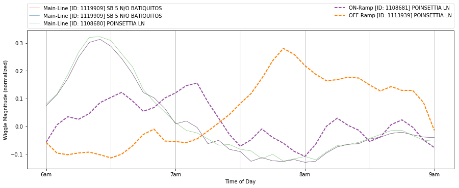

```python
plot_ramp_wiggles( rampid=1113939, links=False )
```

### I-5 South, Encinitas Blvd. (6 - 9am) [[Google Maps]](https://www.google.com/maps/place/33.048438,-117.287351)

The on-ramp/off-ramp pair at Encinitas Blvd. also appears to service a mostly-residential area. While the on-ramp oscillation (dashed orange line **---**) minima do not always fall exactly on the hour/half-hour, the local maxima are always located *between* the hour/half-hour marks. In particular we see the largest spike between 7 and 7:30am, likely workers entering the highway to arrive at their workplace by 8am.

The off-ramp oscillation (dashed blue line **---**) seems to indicate some ammount of commercial activity at this location; there are identifiable local maxima just prior to each hour 7, 8, and 9am.

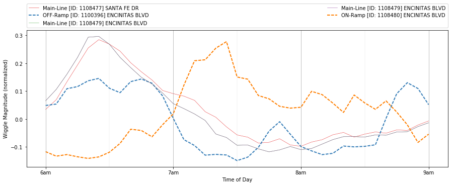

```python
plot_ramp_wiggles( rampid=1100396, links=False )
```

### I-5 South, Lomas Santa Fe Dr. (6 - 9am) [[Google Maps]](https://www.google.com/maps/place/32.995868,-117.256708)

The on-ramp/off-ramp at Lomas Santa Fe Drive appears to have a larger commercial component than the previous stations. An examination of the location on Google maps reveals a number of businesses and two schools immediate adjacent the highway. Accordinly, the off-ramp oscillations (dashed blue line **---**) appear to validate another part of the hypothesis. There are local maxima in the off-ramp oscillations just prior to the hour and half-hour, consistent with workers exiting the highway just prior to typical work hours (7, 8, and 9am).

Regarding the on-ramp oscillations (dashed orange line **---**), we can still see the local minima occuring at or near the hour/half-hour mark, as hypothesized.

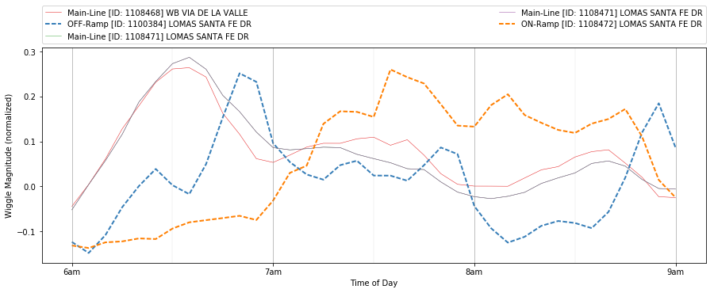

```python
plot_ramp_wiggles( rampid=1100384, links=False )
```

### I-5 South, Clairmont Dr. (6 - 9am) [[Google Maps]](https://www.google.com/maps/place/32.791448,-117.207392)

The data subset for Clairmont Drive only includes on-ramp data and appears to be a heavily residential entrance point (Google maps). As shown below, a portion of the hypothesis seems to hold: the on-ramp local minima are almost exactly located on the hour/half-hour marks (dashed blue line **---**). Additionally, the on-ramp flow oscillations seem to mirror the main-line flow very closely (in frequency if not magnitude).

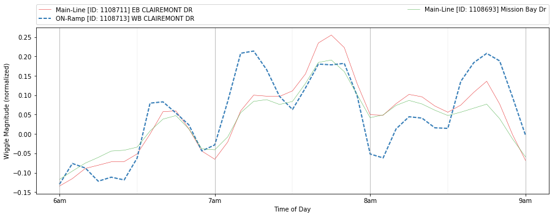

```python
plot_ramp_wiggles( rampid=1108713, links=False )
```

### I-5 South, La Jolla Village (4 - 7pm) [[Google Maps]](https://www.google.com/maps/place/32.869675,-117.229543)

In contrast to the previous stations, the on-ramp at La Jolla Village services an area that is almost entirely commercial (also includes schools). With this in mind, we can validate another portion of the hypothesis: evening on-ramp flow local maxima occur just after the hour/half-hour. As the on-ramp mean flow below illustrates (dashed blue line **---**), this appears to hold true (with the possible exception of the pseudo-peak just after 5:30pm). This behavior is consistent with workers departing from there place of work after working hours (5pm for example).

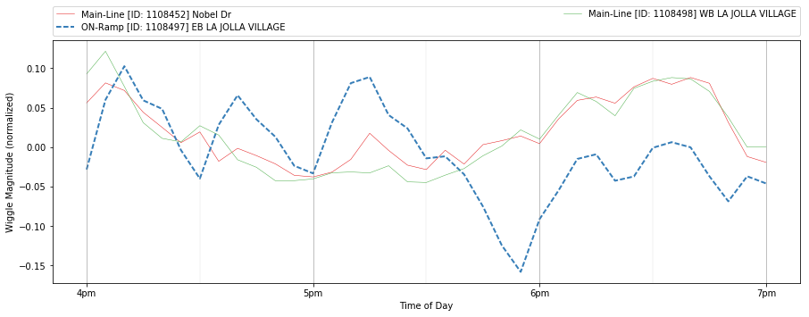

```python
plot_ramp_wiggles( t_min=16, t_max=19, rampid=1108497, links=False )
```

### I-5 South, Old Town Ave. (4 - 7pm) [[Google Maps]](https://www.google.com/maps/place/32.746784,-117.191904)

The on-ramp/off-ramp at Old Town Ave. services a large commercial (and military, in this case) area. In the on-ramp mean flow oscillations (dashed orange line **---**), we can see a very strong set of peaks just after each hour, in addition to a set of smaller peaks at each half-hour. As mentioned above, this is entirely consistent with workers leaving their place of business at the end of the workday.

Perhaps a bit surprisingly, the off-ramp flow (dashed green line **---**) appears to nearly show the inverse of the on-ramp flow (the off-ramp maxima appear to occur very close to the on-ramp minima).

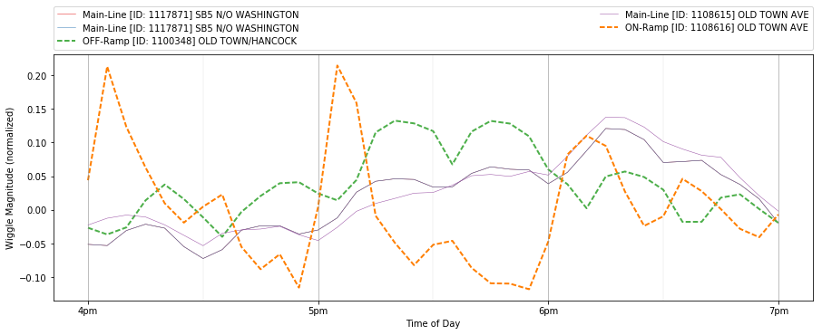

```python
plot_ramp_wiggles( t_min=16, t_max=19, rampid=1100348, links=False )
```

### I-5 South, Mission Ave. (6 - 9am) [[Google Maps]](https://www.google.com/maps/place/33.200618,-117.373434)

Perhaps one of the most interesting exit/entrance points on our sample highway is located at Mission Ave. This pair of on-ramp/off-ramps services a residential-heavy area. Accordingly, the on-ramp mean flow (dashed purple line **---**) follows the hypothesis with local minima at (or near) the hour/half-hour marks.

However, there is a rather unexpected large spike in the off-ramp mean oscillation (dashed orange line **---** between 7 and 7:30am) even while the remainder of the line is relatively free from oscillations.

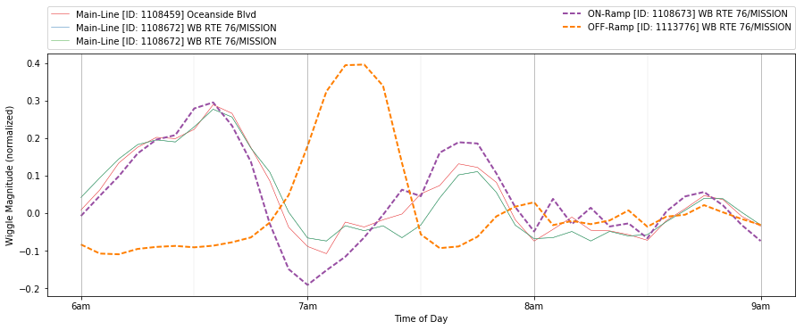

```python
plot_ramp_wiggles( rampid=1113776, links=False )
```

### I-5 South, Mission Ave., Oceanside High School [[Google Maps]](https://www.google.com/maps/place/33.200618,-117.373434)

As it would turn out, the Mission Ave. exit leads directly to Oceanside High School. Additional investigation reveals that the first period at this school starts at 7:30am. [[Oceanside HS Bell Schedule]](https://ohs-ousd-ca.schoolloop.com/BellSchedule)

This appears to explain the spike in off-ramp traffic at this location just prior to 7:30am; students are arriving at the school before the first period.

[figure not shown]

```python
Image("oceanside_highschool.png", width=400)
```

### Results

The juxtaposition of the on-ramp/off-ramp oscillations and the main-line oscillations produced some interesting results. While the hypotheses are not strongly exhibited in every station, they do appear to be at least partially represented. Additionally, highly homogenous areas (residential, commercial) appear to show the posited behaviors quite well.

Also, residential area on-ramp (mornings) and off-ramp (evenings) flow does not appear as stark as commercial areas. This is potentially because workers have varying commute times and likely leave for work (and arrive home) at differing times.

### Conclusions

While perhaps not a rigorous proof, the ramp-vs-main-line graphs are compelling none the less. There appears to be a correlation between the on-ramp/off-ramp flow and main-line flow that indicates the main-line oscillations are not an artifact of the data collection process.

To further explore this relationship, some potential additional steps may include the following:

- Filter the data by weekday-only
- Include both north *and* south directions
- Analyze additional highways